# README

## `drat` Repository for easy forking

`drat` ([CRAN](https://cran.r-project.org/package=drat), [GitHub](https://github.com/eddelbuettel/drat), [docs](https://eddelbuettel.github.io/drat)) makes it easy to host your own CRAN-like repositories for packages (or [data](https://journal.r-project.org/archive/2017/RJ-2017-026/index.html)).

Many users have started their own `drat` repo by forking the original [GitHub repo](https://github.com/eddelbuettel/drat) – but as time passes this *code* repo accumulates more *code* for `drat`, as well as [documentation](https://eddelbuettel.github.io/drat) making it less of an ideal place to start for *your own* repo. So this repo offers an alternative:

- Just fork this repo into your own domain, and you have a working `drat` repo.
- Enable [GitHub Pages](https://docs.github.com/en/github/working-with-github-pages) with the `docs/` folder in the main branch:

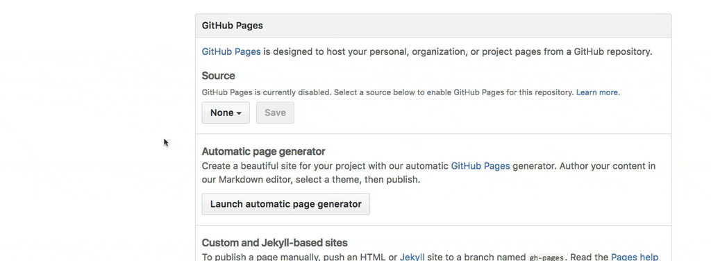

Note, however, that you currently **must** use the `drat` package directly from its [GitHub repo](https://github.com/eddelbuettel/drat) in order to use GitHub Pages off `docs/` in the main branch—and you need to enable this, e.g. via `options(dratBranch="docs")` as the *released* version only supports a `gh-pages` branch. So in a sense this repo is currently “experimental” as is the support in the not-yet-released `drat` version.

This repo was initiated (using command `dratPackage()`) with the source and windows binary of the last CRAN release of `drat`. You can delete either or both (for example via command `pruneRepo()`) and then add your own (via `insertPackage()`).

### Author

Dirk Eddelbuettel

### License

GPL (>= 2)